# SKOC62: Forskningsmetoder i strategisk kommunikation VT24

Quantitative methods workshops 1 — 4

Author

nils.holmberg@isk.lu.se

## 0.1 Introduction

[interactive chart not shown]

- SPSS download student version: [link](https://www.lu.se/studera/livet-som-student/it-tjanster-support-och-driftinfo/programvara)
- SPSS canvas data file: [link](https://canvas.education.lu.se/courses/21228/files/3453815/download?download_frd=1)
- SPSS tutorial in english: [link](https://www.lse.ac.uk/Methodology/Software-tutorials/SPSS-tutorials)
- SPSS tutorial in swedish: [link](https://www.graduateschool.sam.lu.se/current-students/student-links-and-resources/methods-resources-thesis-writing/how-use-spss)
- Observe that instructions become less and less detailed as you work your way through the tasks.
- Open SPSS. Log into the course website at Canvas. Download the file Communicative Organizations Database.
- **SUPER IMPORTANT!! Save your data file and all changes so you can use it for the following workshops! Also save your output files or copy paste relevant parts to another document if you want to remember what you did in the previous workshop!**

# 1 Workshop: Descriptive statistics

- https://nils-holmberg.github.io/scom-r/edu/scom-skoc62/workshop-1.html

# 2 Workshop: Data transformation

- https://nils-holmberg.github.io/scom-r/edu/scom-skoc62/workshop-2.html

# 3 Workshop: Bivariate analysis

- https://nils-holmberg.github.io/scom-r/edu/scom-skoc62/workshop-3.html

# 4 Workshop: Multivariate analysis

## 4.1 Multiple regression analysis

1. Create a model using multiple regression analysis `Analyze -> Regression -> Linear`.
2. Under Dependent, enter your dependent variable (`index_infoaccess`, Workshop #3 task 1a). Under Independent(s), enter your independent variables: `Age` in years (see Workshop #2 task 2), `dummy_gender`, `Org_type`, `dummy_manager` and `dummy_communicator` (Workshop #3 task 3). Click OK.
3. Choose `Method, Enter`.
4. Under Statistics, choose `Estimates, Confidence intervals, Model fit, Descriptives`. Under Residuals: `Casewise diagnostics, Outliers`.
5. Under Options, choose `Exclude cases pairwise`.
6. Under Plots, put `*ZRESID` in Y box and `*ZPRED` in X box; tick the box for Normal probability plot. Click OK to run regression analysis.

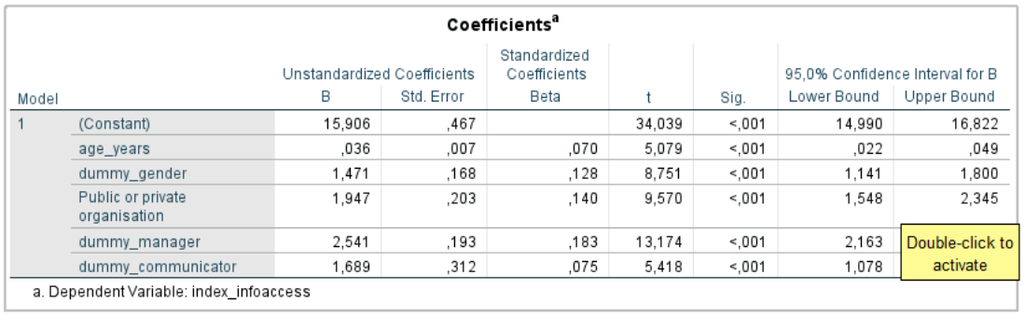

model

7. Correlations: check for multicollinearity (no bivariate above 0.7)
8. Normal PP plot: check for normality (should be straight diagonal)
9. Scatterplot: check for homoscedasticity, (should have rectangular shape with most scores in the centre)
10. ANOVA: F-test tells you whether model is useful (should be significant).
11. Model summary: R squared tells you how much of variance in the dependent variable can be regressed to the independent variables.
12. Coefficients: What variables have significant coefficients? Under Standardized coefficients, note positive/negative relationship and the relative size of the coefficients.
13. How do you interpret the model?
14. Try to take out one or two independent variables. How does it affect the R square?

**THAT’S IT FOR TODAY! REMEMBER TO SAVE YOUR DATA AND OUTPUT FILES (THOSE ARE TWO DIFFERENT OPERATIONS)!**

- [scom-r website](https://nils-holmberg.github.io/scom-r/)